# HW2

Ramtin Boustani - SUID# 05999261

# Problem 1

**Exercise 1 from section 10.7**

### (a)

For simiplicity ignoed $\sum_{}$

$\ (x_{ij} - x_{i\hat{j}})^2$  
$\ = ((x_{ij} - \overline{x_{kj}}) - (x_{i\hat{j}} - \overline{x_{kj}}))^2$  
$\ = ((x_{ij} - \overline{x_{kj}})^2 + (x_{i\hat{j}} - \overline{x_{kj}})^2 -2(x_{ij} - \overline{x_{kj}})(x_{i\hat{j}} - \overline{x_{kj}}) )$  
If expanding the above statement and assuming $\ (x_{ij})^2 = (x_{i\hat{j}})^2$ we will we have the other side statement  
$\ = 0 + 2(x_{ij} - \overline{x_{kj}})^2$

### (b)

Algorithm 10.1 is a iterative gready algorithm that converge to the local minimum. In every step by assiging ponits to each cluster’s centroid we are minmizing inside cluster variance and in genral decreasing distance between clusters.

# Problem 2

**Exercise 2 from section 10.7**

### (a)

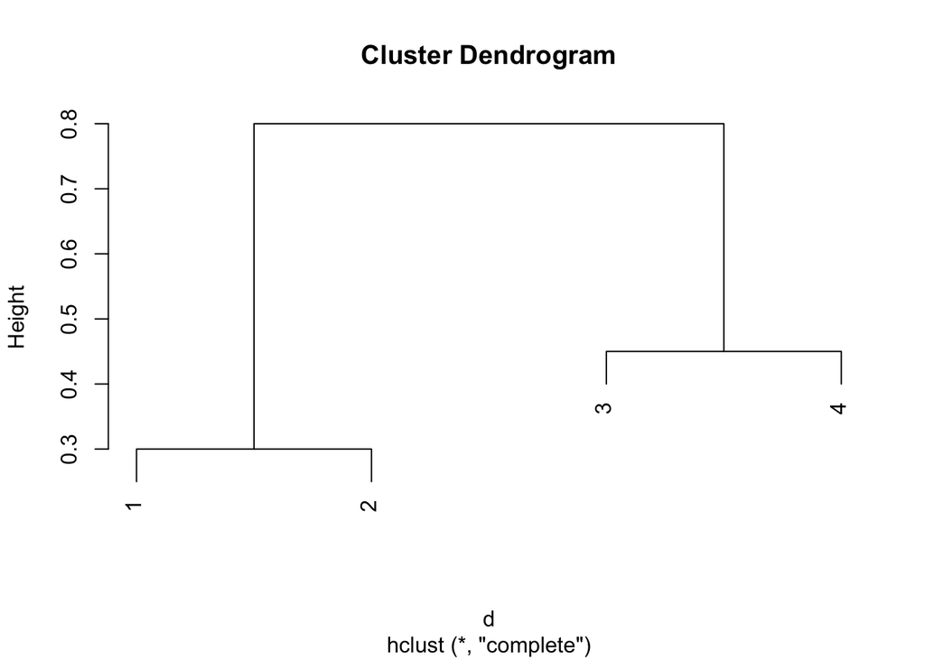

```r
C = matrix( c(0, 0.3, 0.4, 0.7,
              0.3, 0, 0.5, 0.8,
              0.4, 0.5, 0, 0.45,
              0.7, 0.8, 0.45, 0),
            nrow = 4, ncol = 4)
d = as.dist(C)
hc = hclust(d, method = "complete")
plot(hc)
```

### (b)

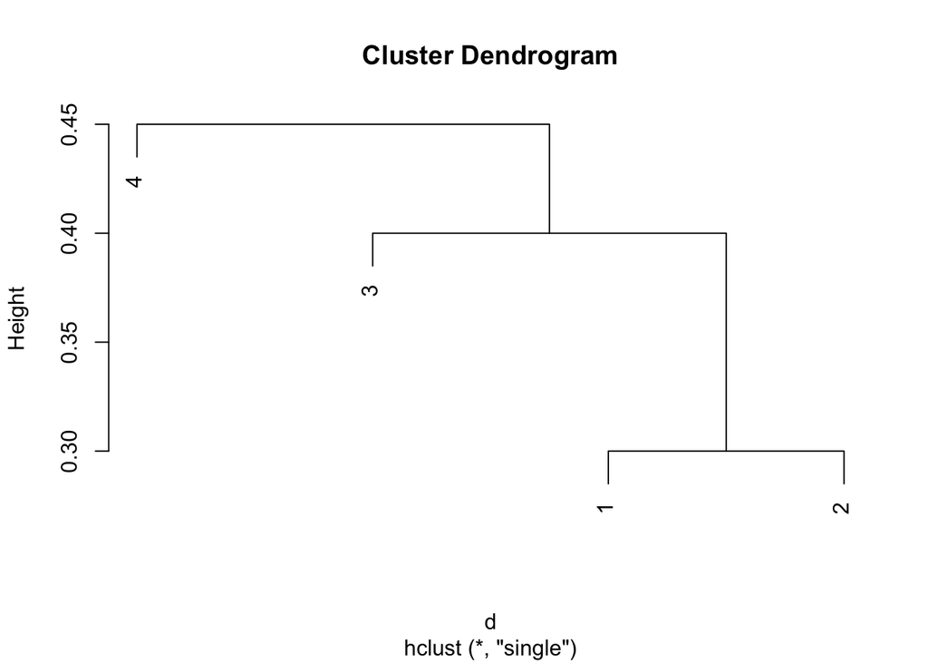

```r
hc = hclust(d, method = "single")
plot(hc)
```

### (c)

(1,2) –> cluster A  
(3,4) –> clustet B

### (d)

((1,2), 3) –> cluster A  
(4) –> clustet B

### (e)

Swapping columns 1 & 2  
Swapping columns 3 & 4

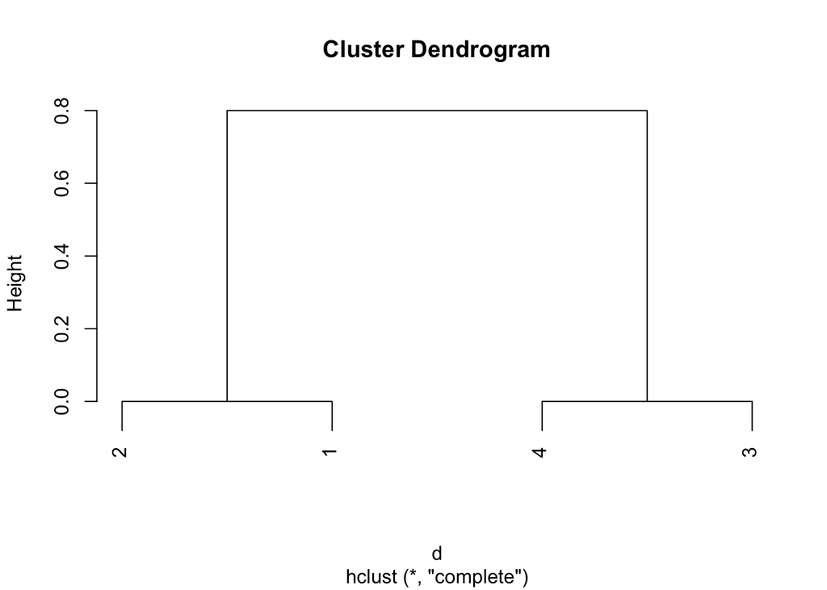

```r
C2 = matrix(c(C[,2], C[,1], C[,4], C[,3]), nrow = 4, ncol = 4, byrow = FALSE)
d = as.dist(C2)
hc = hclust(d, method = "complete")
plot(hc, labels=c(2,1,4,3))
```

# Problem 3

**Exercise 9 from section 10.7**

### (a)

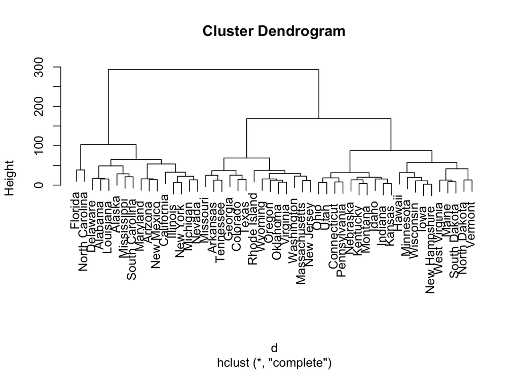

```r
d = dist(USArrests, method = "euclidean")
hc.complete = hclust(d, method = "complete")
plot(hc.complete)
```

### (b)

```r
cutree(hc.complete, k=3)
```

```
##        Alabama         Alaska        Arizona       Arkansas     California
##              1              1              1              2              1
##       Colorado    Connecticut       Delaware        Florida        Georgia
##              2              3              1              1              2
##         Hawaii          Idaho       Illinois        Indiana           Iowa
##              3              3              1              3              3
##         Kansas       Kentucky      Louisiana          Maine       Maryland
##              3              3              1              3              1
##  Massachusetts       Michigan      Minnesota    Mississippi       Missouri
##              2              1              3              1              2
##        Montana       Nebraska         Nevada  New Hampshire     New Jersey
##              3              3              1              3              2
##     New Mexico       New York North Carolina   North Dakota           Ohio
##              1              1              1              3              3
##       Oklahoma         Oregon   Pennsylvania   Rhode Island South Carolina
##              2              2              3              2              1
##   South Dakota      Tennessee          Texas           Utah        Vermont
##              3              2              2              3              3
##       Virginia     Washington  West Virginia      Wisconsin        Wyoming
##              2              2              3              3              2
```

### (c)

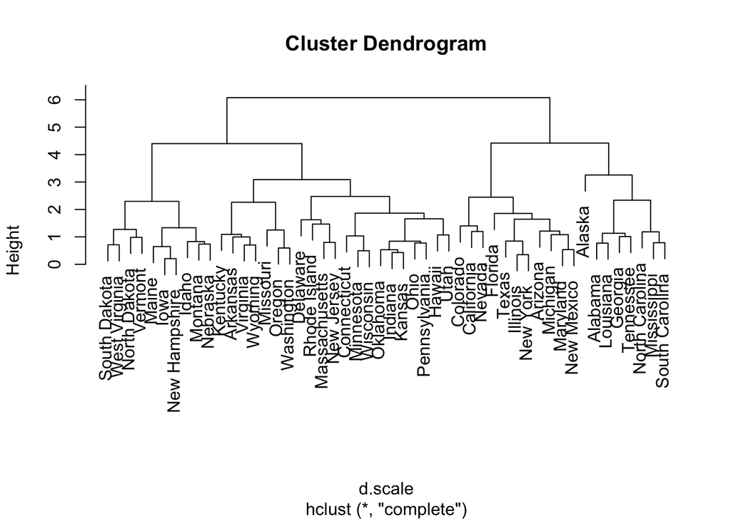

```r
d.scale = dist(scale(USArrests), method = "euclidean")
hc.complete.scale = hclust(d.scale, method = "complete")
plot(hc.complete.scale)
```

### (d)

# Problem 4

**Exercise 10 from section 10.7**

### (a)

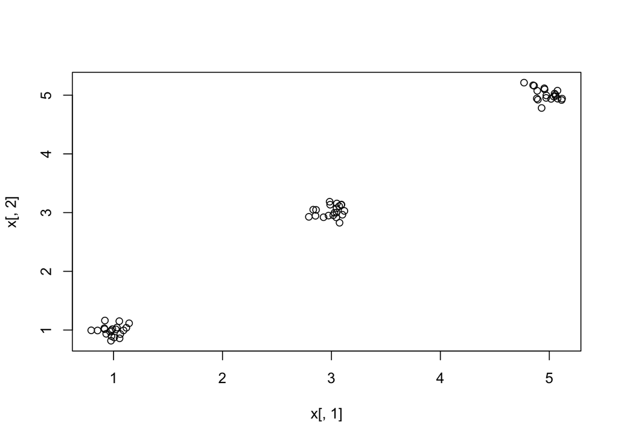

```r
set.seed(101)
x = matrix(rnorm(60*50, mean=0, sd=0.1), 60,50)
#xmean = matrix(rnorm(3*50, sd=4), 3,50)
#which= rbind( matrix(r(7,20*50),20,50), matrix(rep(10,20*50),20,50), matrix(rep(20,20*50),20,50))
x[1:20,1]=1+x[1:20,1]
x[1:20,2]=1+x[1:20,2]
x[21:40,1]=3+x[21:40,1]
x[21:40,2]=3+x[21:40,2]
x[41:60,1]=5+x[41:60,1]
x[41:60,2]=5+x[41:60,2]
#View(x)
#x=x+which
#data = rbind(data, matrix(rnorm(20*50, mean = 60, sd = 2), ncol = 50))
#data = rbind(data, matrix(rnorm(20*50, mean = 120, sd = 2), ncol = 50))
#data = matrix(rnorm(20 * 3 * 50, mean = 0, sd = 0.001), ncol = 50)
plot(x[,1],x[,2])
```

```r
true.labels <- c(rep(1, 20), rep(2, 20), rep(3, 20))
```

### (b)

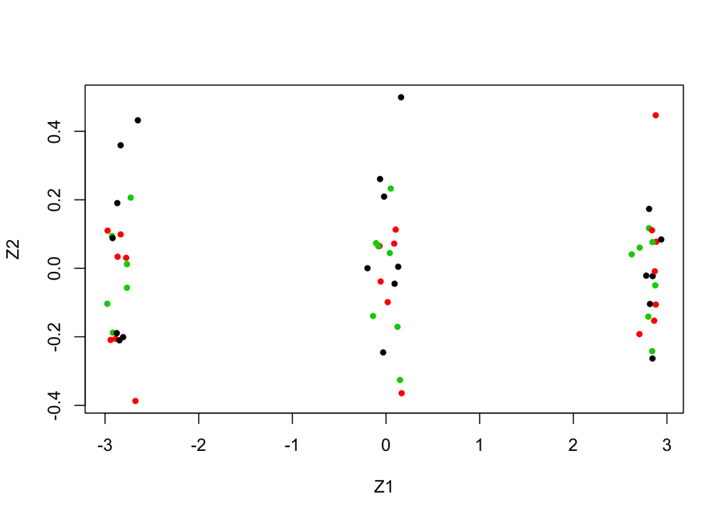

```r
pr.out = prcomp(x)
plot(pr.out$x[,1:2], col = 1:3, xlab = "Z1", ylab = "Z2", pch=20)
```

### (c)

```r
km.out=kmeans(x,3, nstart=20)
table(true.labels, km.out$cluster)
```

```
##
## true.labels  1  2  3
##           1  0  0 20
##           2  0 20  0
##           3 20  0  0
```

### (d)

```r
km.out=kmeans(x,2, nstart=20)
km.out$cluster
```

```
##  [1] 1 1 1 1 1 1 1 1 1 1 1 1 1 1 1 1 1 1 1 1 2 2 2 2 2 2 2 2 2 2 2 2 2 2 2
## [36] 2 2 2 2 2 2 2 2 2 2 2 2 2 2 2 2 2 2 2 2 2 2 2 2 2
```

```r
table(true.labels, km.out$cluster)
```

```
##
## true.labels  1  2
##           1 20  0
##           2  0 20
##           3  0 20
```

clusters of 2 & 3 are merged!

### (e)

```r
km.out=kmeans(x,4, nstart=20)
km.out$cluster
```

```
##  [1] 4 3 4 3 4 4 4 4 3 3 3 4 4 3 4 4 4 3 3 4 1 1 1 1 1 1 1 1 1 1 1 1 1 1 1
## [36] 1 1 1 1 1 2 2 2 2 2 2 2 2 2 2 2 2 2 2 2 2 2 2 2 2
```

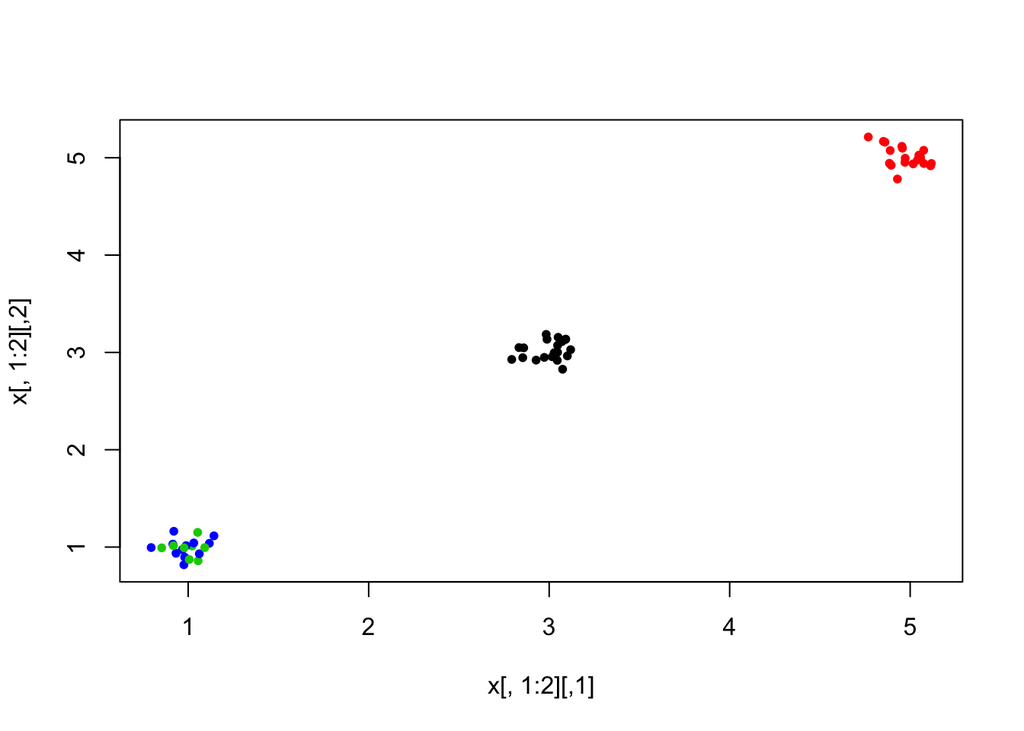

```r
plot(x[,1:2], col= km.out$cluster, pch=20)
```

### (f)

```r
km.out = kmeans(pr.out$x[,1:2], 3, nstart = 20)
table(true.labels, km.out$cluster)
```

```
##
## true.labels  1  2  3
##           1  0 20  0
##           2 20  0  0
##           3  0  0 20
```

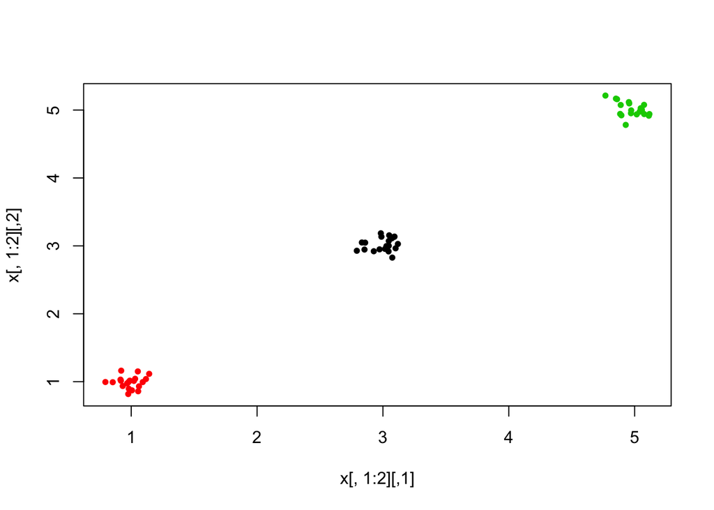

```r
plot(x[,1:2], col= km.out$cluster, pch=20)
```

### (g)

```r
km.out = kmeans(scale(x) , 3, nstart = 20)
table(true.labels, km.out$cluster)
```

```
##
## true.labels  1  2  3
##           1  0 13  7
##           2  7  8  5
##           3 17  2  1
```

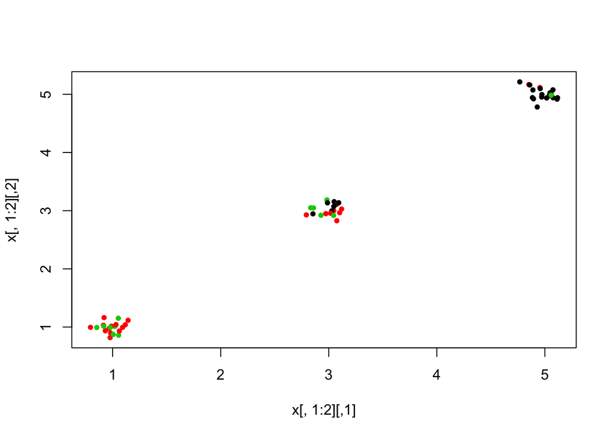

```r
plot(x[,1:2], col= km.out$cluster, pch=20)
```

Not good clutering result due to minmizing distance between observations